**Импорт библиотек:**

```python
import pandas as pd
import numpy as np
import seaborn as sns
import matplotlib.pyplot as plt

from sklearn.model_selection import train_test_split
import category_encoders as ce
from sklearn.preprocessing import StandardScaler
from sklearn.model_selection import KFold
from imblearn.over_sampling import ADASYN

from sklearn.metrics import balanced_accuracy_score
from sklearn.metrics import accuracy_score
from sklearn.metrics import confusion_matrix
from sklearn.metrics import precision_score
from sklearn.metrics import recall_score
from sklearn.metrics import f1_score
from sklearn.metrics import average_precision_score
from sklearn.metrics import precision_recall_curve
from sklearn.metrics import auc

from sklearn.linear_model import LogisticRegression
from sklearn.ensemble import RandomForestClassifier
from sklearn.tree import DecisionTreeClassifier
from sklearn.ensemble import ExtraTreesClassifier
from xgboost.sklearn import XGBClassifier
from catboost import CatBoostClassifier

import warnings
warnings.filterwarnings('ignore')
```

```python
import plotly.express as px
import plotly.io as pio
pio.renderers.default = 'png'
```

# Домашняя работа №1

## Датасет - [HR Analysis Case Study](https://www.kaggle.com/datasets/shivan118/hranalysis?datasetId=829052&sortBy=voteCount)

### План работы:

- Загрузите данные;
- Опишите задачу словами. В том числе напишите, что значит каждый признак;
- Разбейте данные на обучающую и тестовую выборки;
- Визуализируйте данные из обучающей выборки. В частности, имеет смысл построить диаграммы рассеивания для количественных признаков. Построить гистограммы распределений и т.п. Вычислить основные характеристики (среднее, разброс, корреляционную матрицу и т.д.). Интерпретируйте результаты;
- Обработать пропущенные значения (или убедиться, что их нет);
- Исключить нерелевантные признаки (объяснить, как вы их нашли);
- Если необходимо, то обработать коррелированные признаки;
- Обработать категориальные признаки;
- Провести масштабирование (или объяснить, почему в вашем случае она не нужна);
- Вам может понадобиться другая предобработка. Например, если в вашем датасете есть текстовые признаки с уникальными значениями (например, аннотации товаров, отзывы пользователей, другие тексты), как в двух последних датасетах из перечисленных, то вам понадобится этап извлечения признаков, т.е. простые методы NLP, как, например, bag-of-words. Воспользуйтесь библиотеками re, nltk;
- После шагов 5–10 разумно вернутся к шагу 4 (а может, возвращаться к нему после каждого из этапов 5–10.
- Попробуйте как минимум 3 метода классификации (регрессии). Объясните ваш выбор. Найдите значения метрик на обучающей и тестовой выборке. Сделайте вывод;
- На одном из методов (объясните выбор) найдите оптимальное значение параметров. Постройте график зависимости ошибок (на обучающей выборке и валидационной/CV) от значения гиперпарамтра. Для найденного оптимального значения параметра (параметров) снова обучите модель. Сделайте вывод;
- Довольны ли вы результатами? В частности, если классы не сбалансированы, то результат может оказаться неприемлемым. В этом случае можете применить методы балансировки из библиотеки imbalanced-learn;
- Сделать общие выводы.

### Загрузка данных

Заранее я скачала данные с kaggle, исходные данные находятся в папке archive.

```python
data = pd.read_csv('archive/train.csv', header=0, sep=',')
```

```python
data.head()
```

|  | employee_id | department | region | education | gender | recruitment_channel | no_of_trainings | age | previous_year_rating | length_of_service | KPIs_met >80% | awards_won? | avg_training_score | is_promoted |
| --- | --- | --- | --- | --- | --- | --- | --- | --- | --- | --- | --- | --- | --- | --- |
| 0 | 65438 | Sales & Marketing | region_7 | Master's & above | f | sourcing | 1 | 35 | 5.0 | 8 | 1 | 0 | 49 | 0 |
| 1 | 65141 | Operations | region_22 | Bachelor's | m | other | 1 | 30 | 5.0 | 4 | 0 | 0 | 60 | 0 |
| 2 | 7513 | Sales & Marketing | region_19 | Bachelor's | m | sourcing | 1 | 34 | 3.0 | 7 | 0 | 0 | 50 | 0 |
| 3 | 2542 | Sales & Marketing | region_23 | Bachelor's | m | other | 2 | 39 | 1.0 | 10 | 0 | 0 | 50 | 0 |
| 4 | 48945 | Technology | region_26 | Bachelor's | m | other | 1 | 45 | 3.0 | 2 | 0 | 0 | 73 | 0 |

### Опишите задачу словами. В том числе напишите, что значит каждый признак

Признаки:

- employee_id - идентификатор сотрудника, его айди в базе
- department - департамент сотрудника.
- region - ?регион работы сотрудника?
- education - уровень образования
- gender - пол
- recruitment_channel - канал подбора персонала
- no_of_trainings - кол-во пройденных трейнингов
- age - возраст сотрудника
- previous_year_rating - позиция сотрудника в рейтинге прошлого года
- length_of_service - стаж работы
- KPIs_met > 80% - больше ли 80 процентов ключевые показатели эффективности у сотрудника
- awards_won? - есть или нет каких-либо наград у сотрудника
- avg_training_score - средняя оценка за трейнинги
- is_promoted - таргетная переменная - повышен(1) или нет(0)

```python
data.info()
```

```
<class 'pandas.core.frame.DataFrame'>
RangeIndex: 54808 entries, 0 to 54807
Data columns (total 14 columns):
 #   Column                Non-Null Count  Dtype
---  ------                --------------  -----
 0   employee_id           54808 non-null  int64
 1   department            54808 non-null  object
 2   region                54808 non-null  object
 3   education             52399 non-null  object
 4   gender                54808 non-null  object
 5   recruitment_channel   54808 non-null  object
 6   no_of_trainings       54808 non-null  int64
 7   age                   54808 non-null  int64
 8   previous_year_rating  50684 non-null  float64
 9   length_of_service     54808 non-null  int64
 10  KPIs_met >80%         54808 non-null  int64
 11  awards_won?           54808 non-null  int64
 12  avg_training_score    54808 non-null  int64
 13  is_promoted           54808 non-null  int64
dtypes: float64(1), int64(8), object(5)
memory usage: 5.9+ MB
```

### Разбейте данные на обучающую и тестовую выборки

```python
X = data.drop(['is_promoted'], axis=1)
y = data['is_promoted']

X_train, X_test, y_train, y_test = train_test_split(X, y, test_size=0.3, shuffle=True)
```

### Визуализируйте данные из обучающей выборки. В частности, имеет смысл построить диаграммы рассеивания для количественных признаков. Построить гистограммы распределений и т.п. Вычислить основные характеристики (среднее, разброс, корреляционную матрицу и т.д.). Интерпретируйте результаты

#### Начнем с таргетной переменной.

```python
X_train.columns
```

```
Index(['employee_id', 'department', 'region', 'education', 'gender',
       'recruitment_channel', 'no_of_trainings', 'age', 'previous_year_rating',
       'length_of_service', 'KPIs_met >80%', 'awards_won?',
       'avg_training_score'],
      dtype='object')
```

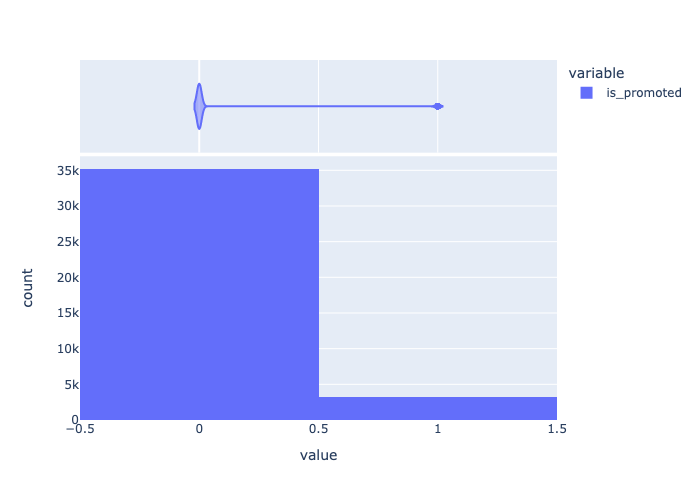

```python
fig = px.histogram(y_train,
                   marginal="violin")
fig.show()
```

```python
y_train.value_counts()
```

```
0    35120
1     3245
Name: is_promoted, dtype: int64
```

```python
data['is_promoted'].value_counts()
```

```
0    50140
1     4668
Name: is_promoted, dtype: int64
```

#### Посмотрим распределение величин числовых переменных:

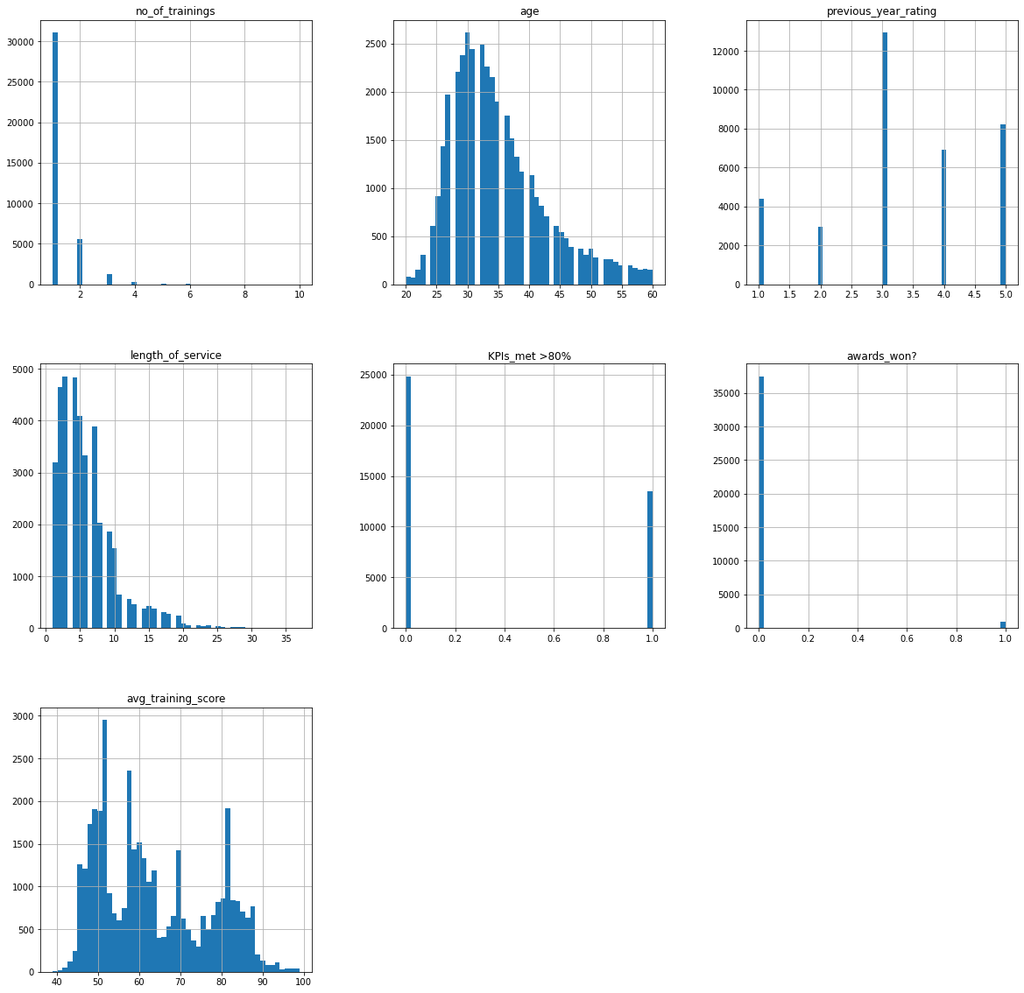

```python
num = (X_train.drop(['employee_id'], axis=1)).columns[X_train.drop(['employee_id'], axis=1).dtypes != 'object']

X_train.hist(column=num, figsize=(20, 20), bins=50)
None
```

#### Рассмотрим поближе, начнем с кол-ва трейнингов:

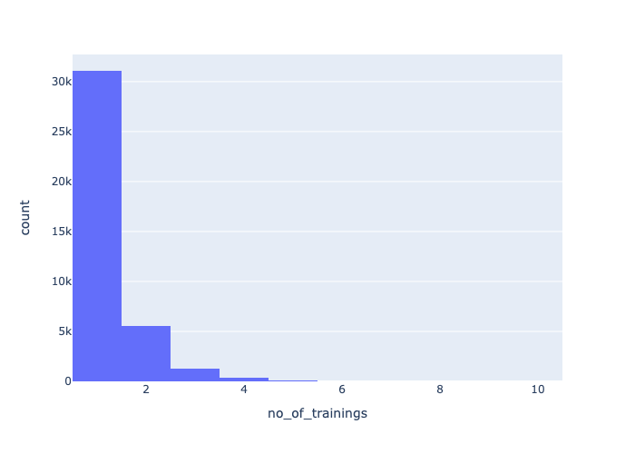

```python
fig = px.histogram(X_train, x='no_of_trainings', nbins=15)
fig.show()
```

```python
X_train['no_of_trainings'].describe()
```

```
count    38365.000000
mean         1.252548
std          0.610317
min          1.000000
25%          1.000000
50%          1.000000
75%          1.000000
max         10.000000
Name: no_of_trainings, dtype: float64
```

```python
trainings = X_train[X_train['no_of_trainings'] == 1]
(trainings['no_of_trainings'].value_counts() / X_train.shape[0]) * 100
```

```
1    81.011338
Name: no_of_trainings, dtype: float64
```

Какое кол-во людей, имеющих х трейнингов, получили повышение:

```python
def distribution_pos_tar(X, y, col):
    X_copy = X.copy()
    X_copy['y'] = y
    b = X_copy.groupby(by=[col])['y'].value_counts()
    print(b)
    print()
    print('Процент людей:')
    array = X_copy[col].unique()
    array.sort()
    for i in array:
        if i not in b: continue
        if b[i].size == 2:
            print(f'i = {i}, % = {(b[i][1] / X_train.shape[0]) * 100}, соотношение тех, кого повысили, к иным - {b[i][1] / b[i][0]}')
        else:
            print(f'i = {i}, % = 0')
```

```python
distribution_pos_tar(X_train, y_train, 'no_of_trainings')
```

```
no_of_trainings  y
1                0    28376
                 1     2704
2                0     5158
                 1      425
3                0     1143
                 1       94
4                0      306
                 1       17
5                0       87
                 1        3
6                0       33
                 1        2
7                0        4
8                0        4
9                0        5
10               0        4
Name: y, dtype: int64

Процент людей:
i = 1, % = 7.048090707676267, соотношение тех, кого повысили, к иным - 0.09529179588384551
i = 2, % = 1.1077805291281115, соотношение тех, кого повысили, к иным - 0.0823962776269872
i = 3, % = 0.24501498761892349, соотношение тех, кого повысили, к иным - 0.08223972003499562
i = 4, % = 0.04431122116512446, соотношение тех, кого повысили, к иным - 0.05555555555555555
i = 5, % = 0.00781962726443373, соотношение тех, кого повысили, к иным - 0.034482758620689655
i = 6, % = 0.0052130848429558195, соотношение тех, кого повысили, к иным - 0.06060606060606061
i = 7, % = 0
i = 8, % = 0
i = 9, % = 0
i = 10, % = 0
```

Видно, что подавляющая часть прошла лишь 1 трейнинг - 81%. Визуально можно предположить, что кол-во трейнингов не особо влияет на повышение.

#### Возраст

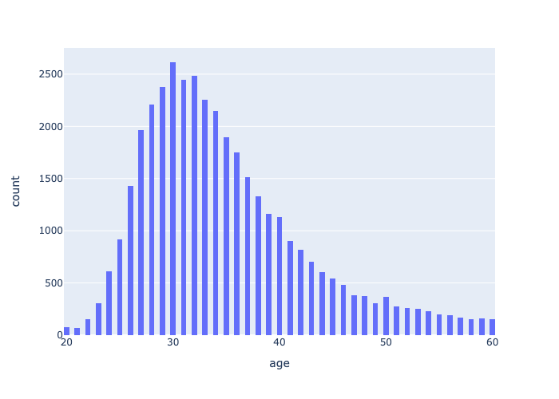

```python
fig = px.histogram(X_train, x='age', nbins=85)
fig.show()
```

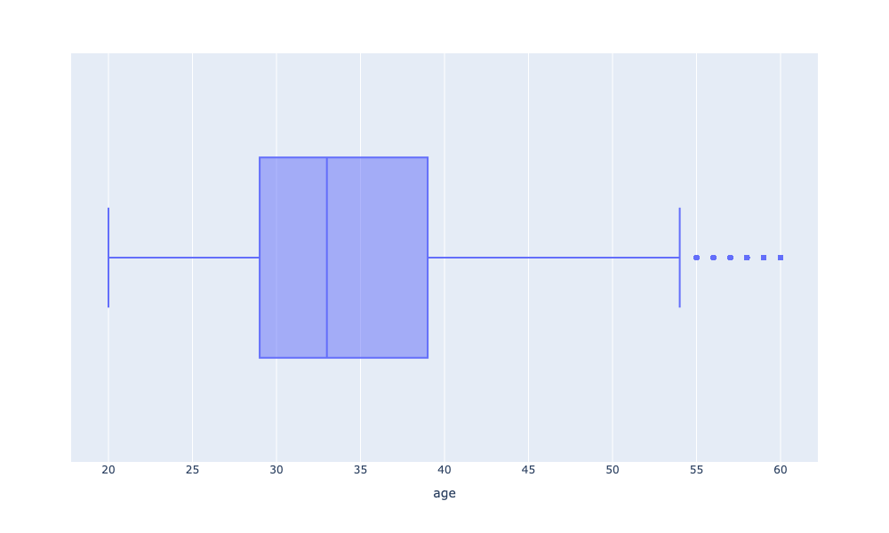

```python
px.box(X_train, x='age', width=1000, height=600)
```

```python
X_train['age'].describe()
```

```
count    38365.000000
mean        34.817412
std          7.690703
min         20.000000
25%         29.000000
50%         33.000000
75%         39.000000
max         60.000000
Name: age, dtype: float64
```

Больше людей 30-летнего возраста. Наибольшее кол-во людей возрастов ~ [29, 33]

#### Стаж работы

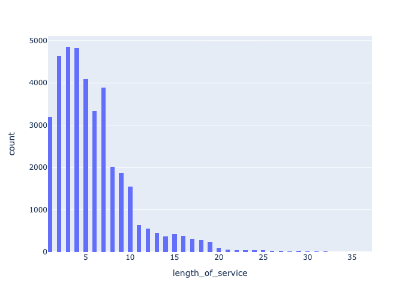

```python
px.histogram(X_train, x='length_of_service', nbins=80)
```

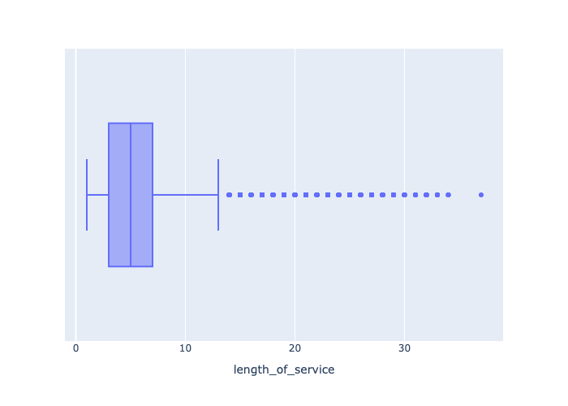

```python
px.box(X_train, x='length_of_service')
```

```python
X_train['length_of_service'].describe()
```

```
count    38365.00000
mean         5.87155
std          4.26106
min          1.00000
25%          3.00000
50%          5.00000
75%          7.00000
max         37.00000
Name: length_of_service, dtype: float64
```

Больше всего людей со стажем больше 3 и меньше 7 лет.

#### Посмотрим есть ли зависимость стажа от возраста:

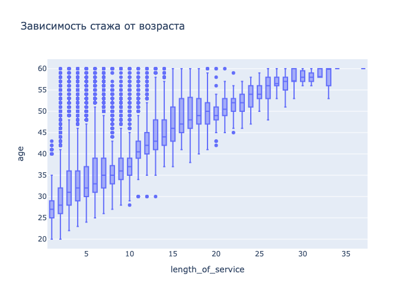

```python
px.box(X_train, y='age', x='length_of_service', title='Зависимость стажа от возраста')
```

Да, судя по данным чем старше человек, тем скорее всего у него большой стаж работы.

#### Позиция сотрудника в рейтинге прошлого года

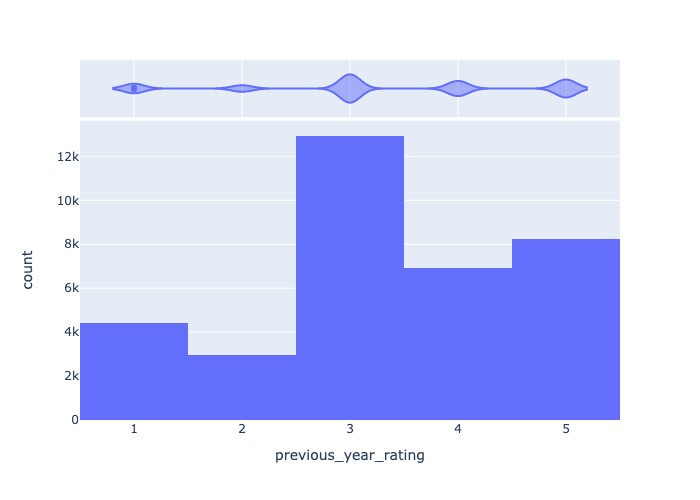

```python
fig = px.histogram(X_train,
                   x='previous_year_rating',
                   marginal="violin")
fig.show()
```

```python
distribution_pos_tar(X_train, y_train, 'previous_year_rating')
```

```
previous_year_rating  y
1.0                   0     4340
                      1       66
2.0                   0     2839
                      1      129
3.0                   0    12002
                      1      946
4.0                   0     6366
                      1      551
5.0                   0     6892
                      1     1329
Name: y, dtype: int64

Процент людей:
i = 1.0, % = 0.17203179981754202, соотношение тех, кого повысили, к иным - 0.015207373271889401
i = 2.0, % = 0.33624397237065035, соотношение тех, кого повысили, к иным - 0.04543853469531525
i = 3.0, % = 2.4657891307181026, соотношение тех, кого повысили, к иным - 0.07882019663389435
i = 4.0, % = 1.436204874234328, соотношение тех, кого повысили, к иным - 0.08655356581841031
i = 5.0, % = 3.4640948781441416, соотношение тех, кого повысили, к иным - 0.1928322692977365
```

Видно, что рейтинг влияет на повышение сотрудника. Больше всего сотрудников рейтинга 3.

#### Показатели KPI

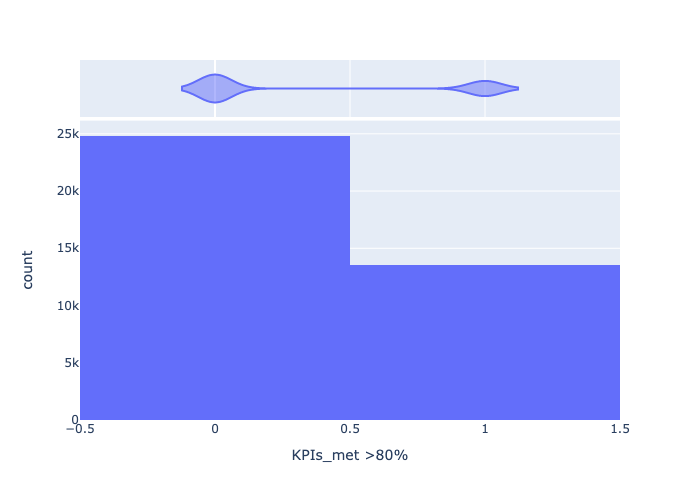

```python
fig = px.histogram(X_train,
                   x='KPIs_met >80%',
                   marginal="violin")
fig.show()
```

```python
distribution_pos_tar(X_train, y_train, 'KPIs_met >80%')
```

```
KPIs_met >80%  y
0              0    23862
               1      984
1              0    11258
               1     2261
Name: y, dtype: int64

Процент людей:
i = 0, % = 2.564837742734263, соотношение тех, кого повысили, к иным - 0.041237113402061855
i = 1, % = 5.8933924149615535, соотношение тех, кого повысили, к иным - 0.2008349618049387
```

Судя по всему данный признак тоже является важным, ведь с выполнением плана - растет процент людей с повышением.

#### Награды у сотрудников

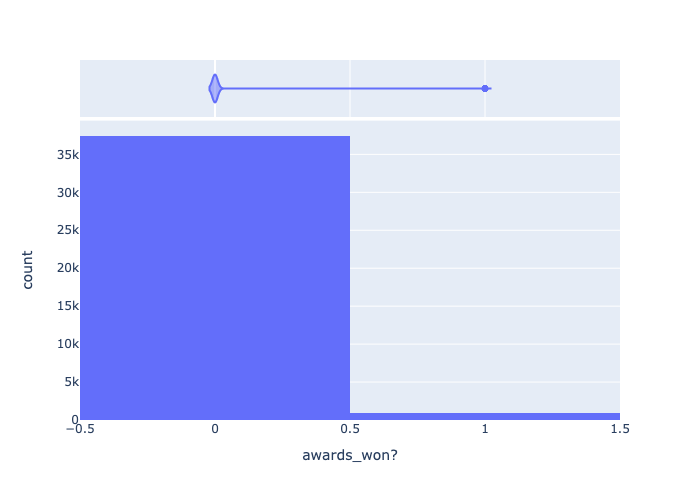

```python
fig = px.histogram(X_train,
                   x='awards_won?',
                   marginal="violin")
fig.show()
```

```python
X_train['awards_won?'].value_counts()
```

```
0    37477
1      888
Name: awards_won?, dtype: int64
```

```python
distribution_pos_tar(X_train, y_train, 'awards_won?')
```

```
awards_won?  y
0            0    34625
             1     2864
1            0      495
             1      381
Name: y, dtype: int64

Процент людей:
i = 0, % = 7.465137495112733, соотношение тех, кого повысили, к иным - 0.08271480144404332
i = 1, % = 0.9930926625830835, соотношение тех, кого повысили, к иным - 0.7696969696969697
```

#### Cредняя оценка за трейнинги

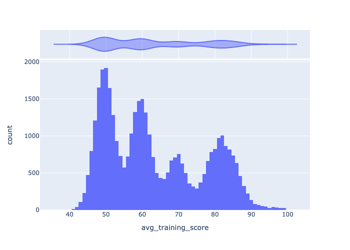

```python
fig = px.histogram(X_train,
                   x='avg_training_score',
                   marginal="violin")
fig.show()
```

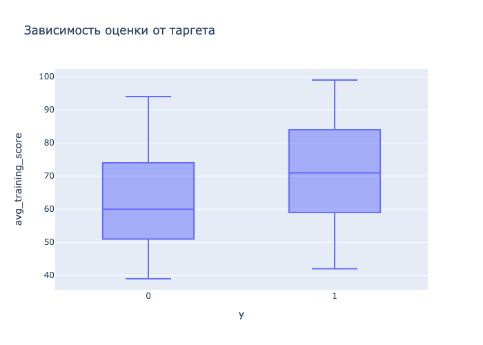

```python
X_copy = X_train.copy()
X_copy['y'] = y_train

px.box(X_copy, x='y', y='avg_training_score', title='Зависимость оценки от таргета')
```

Чем выше оценка - тем охотнее, видимо, людей повышают) Думаю тоже важный признак.

#### Посмотрим распределение категориальных переменных:

```python
cat = (X_train.drop(['employee_id'], axis=1)).columns[X_train.drop(['employee_id'], axis=1).dtypes == 'object']
cat
```

```
Index(['department', 'region', 'education', 'gender', 'recruitment_channel'], dtype='object')
```

#### Департамент:

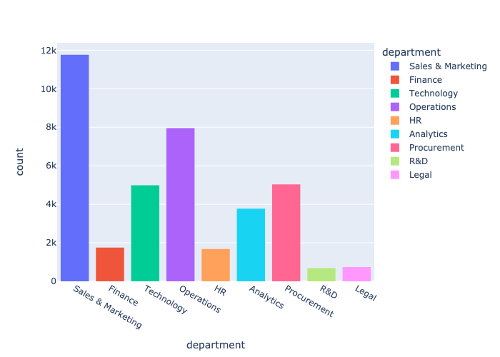

```python
px.histogram(X_train,
             x='department',
             color="department")
```

```python
distribution_pos_tar(X_train, y_train, 'department')
```

```
department         y
Analytics          0     3410
                   1      361
Finance            0     1598
                   1      150
HR                 0     1581
                   1       94
Legal              0      703
                   1       41
Operations         0     7242
                   1      709
Procurement        0     4543
                   1      490
R&D                0      632
                   1       53
Sales & Marketing  0    10886
                   1      880
Technology         0     4463
                   1      529
Name: y, dtype: int64

Процент людей:
i = Sales & Marketing, % = 2.2937573309005606, соотношение тех, кого повысили, к иным - 0.08083777328679037
i = Finance, % = 0.3909813632216865, соотношение тех, кого повысили, к иным - 0.09386733416770963
i = Technology, % = 1.3788609409618142, соотношение тех, кого повысили, к иным - 0.11853013667936366
i = Operations, % = 1.848038576827838, соотношение тех, кого повысили, к иным - 0.09790113228389948
i = HR, % = 0.24501498761892349, соотношение тех, кого повысили, к иным - 0.05945604048070841
i = Analytics, % = 0.9409618141535254, соотношение тех, кого повысили, к иным - 0.10586510263929619
i = Procurement, % = 1.2772057865241757, соотношение тех, кого повысили, к иным - 0.10785824345146379
i = R&D, % = 0.1381467483383292, соотношение тех, кого повысили, к иным - 0.08386075949367089
i = Legal, % = 0.1068682392805943, соотношение тех, кого повысили, к иным - 0.05832147937411095
```

Больше всего людей из департамента продаж и маркетинга, меньше всего - R&D, Legal.

#### Регион:

```python
X_train['region']
```

```
50666    region_12
35484     region_4
30293     region_2
15118     region_4
8682      region_4
           ...
36293    region_22
7260     region_22
13712    region_23
33798    region_23
35493    region_22
Name: region, Length: 38365, dtype: object
```

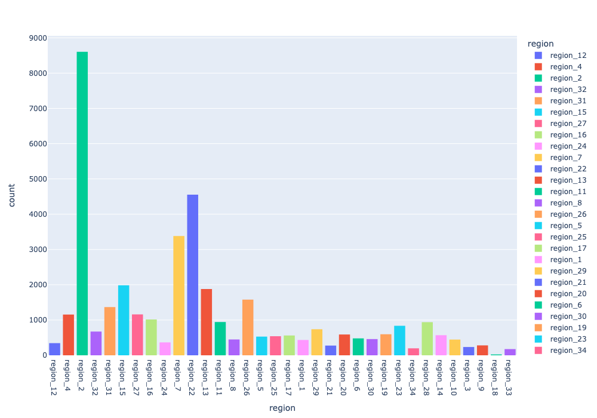

```python
px.histogram(X_train,
             x='region',
             color="region",
             width=1000, height=700)
```

#### Уровень образования:

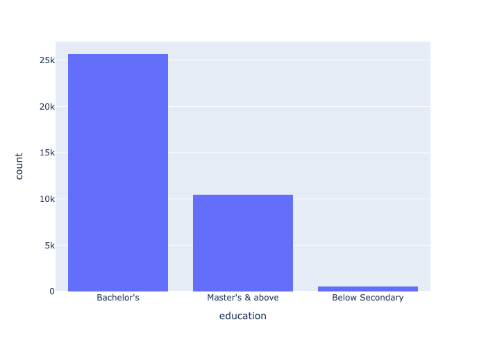

```python
px.histogram(X_train,
             x='education')
```

```python
distribution_pos_tar(X_train, y_train, 'education')
```

```
education         y
Bachelor's        0    23540
                  1     2113
Below Secondary   0      505
                  1       47
Master's & above  0     9388
                  1     1053
Name: y, dtype: int64

Процент людей:
i = Bachelor's, % = 5.507624136582823, соотношение тех, кого повысили, к иным - 0.08976210705182668
i = Master's & above, % = 2.7446891698162386, соотношение тех, кого повысили, к иным - 0.11216446527481892
i = Below Secondary, % = 0.12250749380946174, соотношение тех, кого повысили, к иным - 0.09306930693069307
```

Больше всего людей закончили бакалавриат, однако тех, кто окончил магистратуру, повышают немного чаще.

#### Пол:

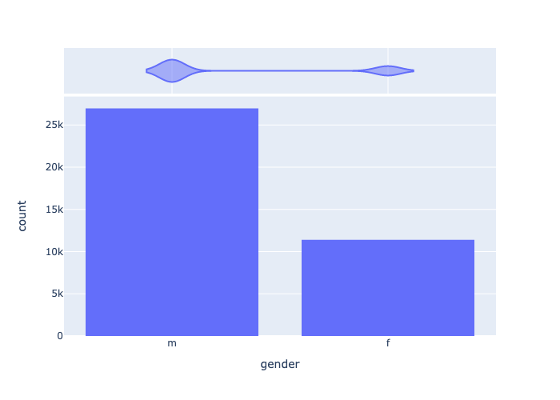

```python
fig = px.histogram(X_train,
                   x='gender',
                   marginal="violin")
fig.show()
```

```python
X_copy = X_train.copy()
X_copy['y'] = y_train

X_copy.groupby('gender')['y'].value_counts()
```

```
gender  y
f       0    10453
        1     1016
m       0    24667
        1     2229
Name: y, dtype: int64
```

```python
print(1016/10453, 2229/24667)
```

```
0.09719697694441787 0.09036364373454413
```

Как видно из гистограммы мужчин больше, чем женщин. Несмотря на дисбаланс, соотношения почти одинаковые. Не думаю, что пол вообще влияет на получение повышения.

#### Канал подбора персонала:

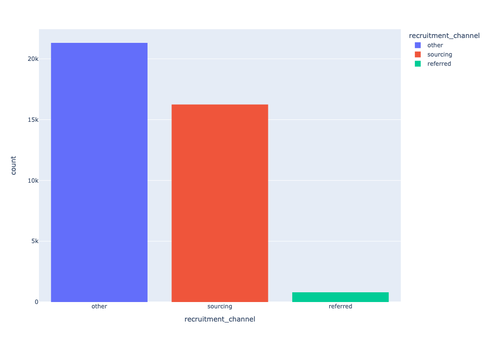

```python
px.histogram(X_train,
             x='recruitment_channel',
             color="recruitment_channel",
             width=1000, height=700)
```

#### Вычислим еще корреляционную матрицу:

```python
X_train.corr().style.background_gradient(cmap='coolwarm').set_precision(2)
```

|  | employee_id | no_of_trainings | age | previous_year_rating | length_of_service | KPIs_met >80% | awards_won? | avg_training_score |
| --- | --- | --- | --- | --- | --- | --- | --- | --- |
| employee_id | 1.00 | -0.01 | 0.00 | -0.00 | 0.01 | -0.00 | 0.01 | -0.00 |
| no_of_trainings | -0.01 | 1.00 | -0.08 | -0.06 | -0.06 | -0.05 | -0.01 | 0.04 |
| age | 0.00 | -0.08 | 1.00 | 0.00 | 0.65 | -0.03 | -0.01 | -0.05 |
| previous_year_rating | -0.00 | -0.06 | 0.00 | 1.00 | -0.00 | 0.35 | 0.03 | 0.08 |
| length_of_service | 0.01 | -0.06 | 0.65 | -0.00 | 1.00 | -0.08 | -0.04 | -0.03 |
| KPIs_met >80% | -0.00 | -0.05 | -0.03 | 0.35 | -0.08 | 1.00 | 0.10 | 0.08 |
| awards_won? | 0.01 | -0.01 | -0.01 | 0.03 | -0.04 | 0.10 | 1.00 | 0.07 |
| avg_training_score | -0.00 | 0.04 | -0.05 | 0.08 | -0.03 | 0.08 | 0.07 | 1.00 |

Подробнее о выводах в пункте **Если необходимо, то обработать коррелированные признаки**

#### Выбросы

Думаю нет смысла читать выбросы у признаков, которые принимают значение 0 и 1. Поэтому я считаю выбросы у числовых признаков, где выбросы могут находиться.

```python
num = ['age', 'length_of_service', 'avg_training_score']
```

```python
outliers = 0

for i in num:
    Q1, Q3 = X_train[i].quantile([.25, .75])
    IQR = Q3 - Q1
    price_lower = Q1 - 1.5*IQR
    price_upper = Q3 + 1.5*IQR

    outliers += (X_train.shape[0] - ((X_train[i] < price_lower) | (X_train[i] > price_upper)).value_counts()[False]) / X_train.shape[0] * 100

outliers
```

```
8.950866675355142
```

### Обработать пропущенные значения (или убедиться, что их нет)

#### Train

```python
cols_null = X_train.columns[X_train.isnull().any()]
missed = pd.DataFrame(X_train[cols_null].isnull().sum().sort_values(ascending=False) / X_train.shape[0], columns=['% NULL'])
missed
```

|  | % NULL |
| --- | --- |
| previous_year_rating | 0.074860 |
| education | 0.044806 |

Так как пропусков немного, то заменим числовые на медиану, а категориальные на часто встречаемые значения.

```python
fill = X_train.apply(lambda s: s.mode()[0] if s.dtype == 'object' else s.median(), axis=0)
X_train_prepared = X_train.fillna(value=fill)
```

#### Test

```python
cols_null = X_test.columns[X_test.isnull().any()]
missed = pd.DataFrame(X_test[cols_null].isnull().sum().sort_values(ascending=False) / X_test.shape[0], columns=['% NULL'])

fill = X_test.apply(lambda s: s.mode()[0] if s.dtype == 'object' else s.median(), axis=0)
X_test_prepared = X_test.fillna(value=fill)

missed
```

|  | % NULL |
| --- | --- |
| previous_year_rating | 0.076142 |
| education | 0.041963 |

### Исключить нерелевантные признаки (объяснить, как вы их нашли)

ID сотрудника - уникальный идентификатор, так что никакого смысла он за собой не несет, поэтому мы его выкинем.

```python
len(X_train['employee_id'].unique()) == X_train.shape[0]
```

```
True
```

```python
X_train_prepared.drop(['employee_id'], axis=1, inplace=True)
X_test_prepared.drop(['employee_id'], axis=1, inplace=True)
```

Также я считаю из анализа - пол не влияет на повышение, поэтому его я тоже удалю.

```python
X_train_prepared.drop(['gender'], axis=1, inplace=True)
X_test_prepared.drop(['gender'], axis=1, inplace=True)
```

### Если необходимо, то обработать коррелированные признаки

Скорее всего возраст мало влияет на повышение, тем более стаж и сам возраст довольно сильно скоррелированны. Поэтому я думаю удалить возраст из признаков и оставить только стаж, так как зачастую за больший стаж нарабатывают больший опыт и шанс на повышение поднимается.

```python
X_train_prepared.drop(['age'], axis=1, inplace=True)
X_test_prepared.drop(['age'], axis=1, inplace=True)
```

### Обработать категориальные признаки

#### Train

```python
cat
```

```
Index(['department', 'region', 'education', 'gender', 'recruitment_channel'], dtype='object')
```

```python
enc = ce.cat_boost.CatBoostEncoder()
enc.fit(X_train_prepared['region'], y_train)
reg_transformed = enc.transform(X_train_prepared['region'])
X_train_prepared['region'] = reg_transformed
```

```python
X_train_prepared = pd.get_dummies(X_train_prepared, drop_first=True)
```

#### Test

```python
enc = ce.cat_boost.CatBoostEncoder()
enc.fit(X_test_prepared['region'], y_test)
reg_transformed = enc.transform(X_test_prepared['region'])
X_test_prepared['region'] = reg_transformed

X_test_prepared = pd.get_dummies(X_test_prepared, drop_first=True)
```

### Провести масштабирование (или объяснить, почему в вашем случае она не нужна)

#### Train

```python
X_train_prepared.columns
```

```
Index(['region', 'no_of_trainings', 'previous_year_rating',
       'length_of_service', 'KPIs_met >80%', 'awards_won?',
       'avg_training_score', 'department_Finance', 'department_HR',
       'department_Legal', 'department_Operations', 'department_Procurement',
       'department_R&D', 'department_Sales & Marketing',
       'department_Technology', 'education_Below Secondary',
       'education_Master's & above', 'recruitment_channel_referred',
       'recruitment_channel_sourcing'],
      dtype='object')
```

```python
scal_col = ['no_of_trainings', 'previous_year_rating', 'length_of_service', 'avg_training_score']
ss = StandardScaler()
Scales_train = pd.DataFrame(ss.fit_transform(X_train_prepared[scal_col]), columns = scal_col, index=X_train_prepared.index)
```

```python
X_train_prepared[scal_col] = Scales_train[scal_col]
```

#### Test

```python
ss = StandardScaler()
Scales_test = pd.DataFrame(ss.fit_transform(X_test_prepared[scal_col]), columns = scal_col, index=X_test_prepared.index)

X_test_prepared[scal_col] = Scales_test[scal_col]
```

### Вам может понадобиться другая предобработка. Например, если в вашем датасете есть текстовые признаки с уникальными значениями (например, аннотации товаров, отзывы пользователей, другие тексты), как в двух последних датасетах из перечисленных, то вам понадобится этап извлечения признаков, т.е. простые методы NLP, как, например, bag-of-words. Воспользуйтесь библиотеками re, nltk

Текстовых признаков нет.

### После шагов 5–10 разумно вернутся к шагу 4 (а может, возвращаться к нему после каждого из этапов 5–10

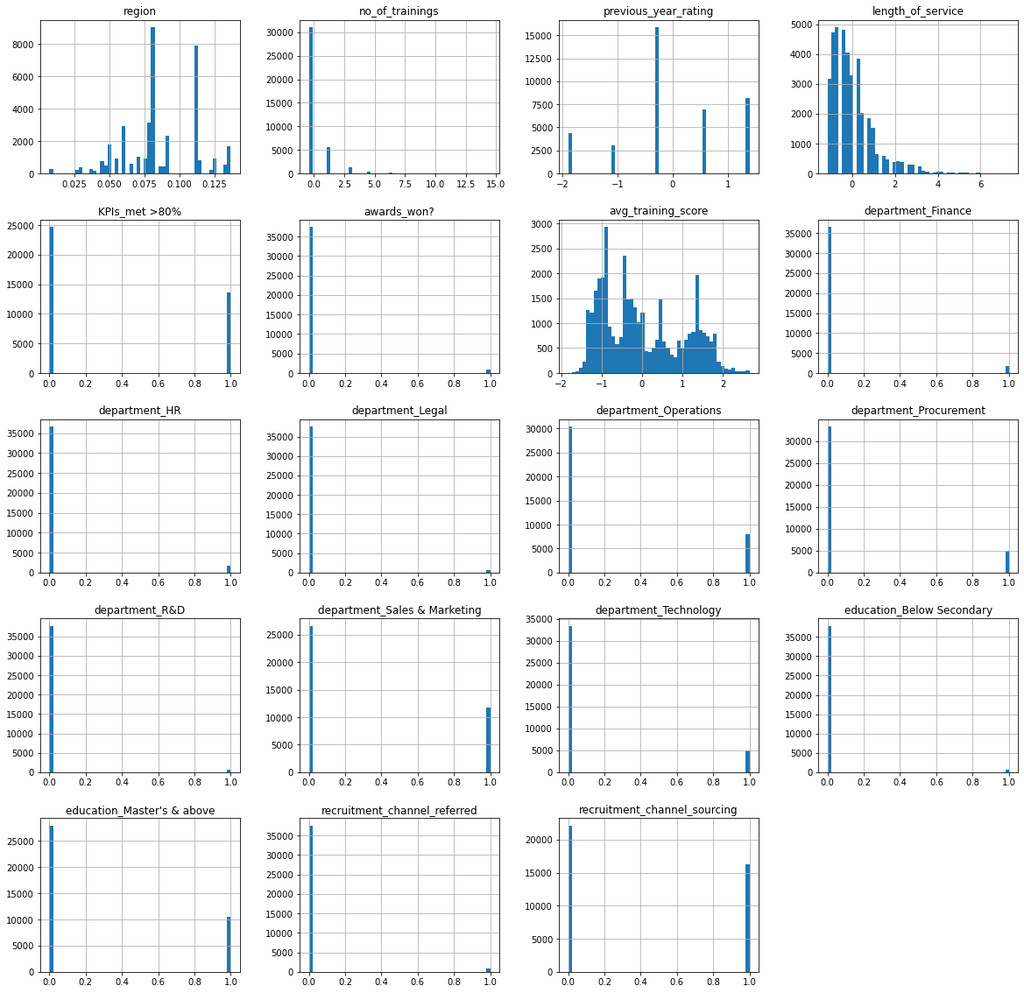

```python
# num = X_train_prepared.columns[X_train_prepared.dtypes != 'object']
# cat = X_train_prepared.columns[X_train_prepared.dtypes == 'object']

X_train_prepared.hist(column= X_train_prepared.columns, figsize=(20, 20), bins=50)
None
```

```python
X_train_prepared.corr().style.background_gradient(cmap='plasma').set_precision(2)
```

|  | region | no_of_trainings | previous_year_rating | length_of_service | KPIs_met >80% | awards_won? | avg_training_score | department_Finance | department_HR | department_Legal | department_Operations | department_Procurement | department_R&D | department_Sales & Marketing | department_Technology | education_Below Secondary | education_Master's & above | recruitment_channel_referred | recruitment_channel_sourcing |
| --- | --- | --- | --- | --- | --- | --- | --- | --- | --- | --- | --- | --- | --- | --- | --- | --- | --- | --- | --- |
| region | 1.00 | 0.04 | 0.07 | 0.03 | 0.07 | 0.01 | 0.02 | 0.01 | 0.01 | 0.00 | -0.01 | 0.01 | 0.04 | -0.01 | -0.02 | 0.01 | 0.12 | 0.04 | -0.01 |
| no_of_trainings | 0.04 | 1.00 | -0.06 | -0.06 | -0.05 | -0.01 | 0.04 | 0.02 | -0.07 | -0.04 | -0.08 | 0.04 | 0.04 | 0.03 | 0.01 | 0.00 | -0.03 | -0.01 | -0.01 |
| previous_year_rating | 0.07 | -0.06 | 1.00 | 0.02 | 0.34 | 0.03 | 0.08 | 0.03 | 0.02 | 0.01 | 0.13 | -0.00 | 0.02 | -0.14 | -0.05 | -0.00 | 0.03 | 0.06 | -0.00 |
| length_of_service | 0.03 | -0.06 | 0.02 | 1.00 | -0.08 | -0.04 | -0.03 | -0.06 | -0.01 | -0.04 | 0.06 | 0.05 | -0.04 | 0.01 | 0.01 | -0.12 | 0.25 | -0.03 | 0.00 |
| KPIs_met >80% | 0.07 | -0.05 | 0.34 | -0.08 | 1.00 | 0.10 | 0.08 | 0.03 | -0.01 | -0.01 | 0.08 | 0.02 | 0.02 | -0.12 | -0.01 | 0.02 | 0.01 | 0.05 | -0.01 |
| awards_won? | 0.01 | -0.01 | 0.03 | -0.04 | 0.10 | 1.00 | 0.07 | 0.01 | -0.00 | -0.00 | -0.00 | 0.00 | -0.00 | -0.01 | 0.01 | -0.00 | -0.00 | -0.00 | -0.01 |
| avg_training_score | 0.02 | 0.04 | 0.08 | -0.03 | 0.08 | 0.07 | 1.00 | -0.05 | -0.21 | -0.04 | -0.12 | 0.19 | 0.21 | -0.65 | 0.48 | 0.01 | 0.03 | 0.03 | -0.01 |
| department_Finance | 0.01 | 0.02 | 0.03 | -0.06 | 0.03 | 0.01 | -0.05 | 1.00 | -0.05 | -0.03 | -0.11 | -0.08 | -0.03 | -0.15 | -0.08 | 0.04 | -0.04 | -0.03 | -0.00 |
| department_HR | 0.01 | -0.07 | 0.02 | -0.01 | -0.01 | -0.00 | -0.21 | -0.05 | 1.00 | -0.03 | -0.11 | -0.08 | -0.03 | -0.14 | -0.08 | 0.06 | 0.01 | 0.03 | -0.01 |
| department_Legal | 0.00 | -0.04 | 0.01 | -0.04 | -0.01 | -0.00 | -0.04 | -0.03 | -0.03 | 1.00 | -0.07 | -0.05 | -0.02 | -0.09 | -0.05 | 0.06 | -0.04 | -0.01 | -0.00 |
| department_Operations | -0.01 | -0.08 | 0.13 | 0.06 | 0.08 | -0.00 | -0.12 | -0.11 | -0.11 | -0.07 | 1.00 | -0.20 | -0.07 | -0.34 | -0.20 | 0.01 | 0.01 | 0.00 | 0.00 |
| department_Procurement | 0.01 | 0.04 | -0.00 | 0.05 | 0.02 | 0.00 | 0.19 | -0.08 | -0.08 | -0.05 | -0.20 | 1.00 | -0.05 | -0.26 | -0.15 | 0.01 | 0.08 | -0.03 | 0.01 |
| department_R&D | 0.04 | 0.04 | 0.02 | -0.04 | 0.02 | -0.00 | 0.21 | -0.03 | -0.03 | -0.02 | -0.07 | -0.05 | 1.00 | -0.09 | -0.05 | -0.02 | 0.04 | 0.00 | -0.01 |
| department_Sales & Marketing | -0.01 | 0.03 | -0.14 | 0.01 | -0.12 | -0.01 | -0.65 | -0.15 | -0.14 | -0.09 | -0.34 | -0.26 | -0.09 | 1.00 | -0.26 | -0.08 | -0.04 | -0.03 | 0.01 |
| department_Technology | -0.02 | 0.01 | -0.05 | 0.01 | -0.01 | 0.01 | 0.48 | -0.08 | -0.08 | -0.05 | -0.20 | -0.15 | -0.05 | -0.26 | 1.00 | 0.04 | 0.03 | 0.08 | -0.02 |
| education_Below Secondary | 0.01 | 0.00 | -0.00 | -0.12 | 0.02 | -0.00 | 0.01 | 0.04 | 0.06 | 0.06 | 0.01 | 0.01 | -0.02 | -0.08 | 0.04 | 1.00 | -0.07 | 0.02 | -0.00 |
| education_Master's & above | 0.12 | -0.03 | 0.03 | 0.25 | 0.01 | -0.00 | 0.03 | -0.04 | 0.01 | -0.04 | 0.01 | 0.08 | 0.04 | -0.04 | 0.03 | -0.07 | 1.00 | -0.03 | 0.00 |
| recruitment_channel_referred | 0.04 | -0.01 | 0.06 | -0.03 | 0.05 | -0.00 | 0.03 | -0.03 | 0.03 | -0.01 | 0.00 | -0.03 | 0.00 | -0.03 | 0.08 | 0.02 | -0.03 | 1.00 | -0.13 |
| recruitment_channel_sourcing | -0.01 | -0.01 | -0.00 | 0.00 | -0.01 | -0.01 | -0.01 | -0.00 | -0.01 | -0.00 | 0.00 | 0.01 | -0.01 | 0.01 | -0.02 | -0.00 | 0.00 | -0.13 | 1.00 |

### Попробуйте как минимум 3 метода классификации (регрессии). Объясните ваш выбор. Найдите значения метрик на обучающей и тестовой выборке. Сделайте вывод

**Я решила попробовать 5 моделей:**

- Логистическая регрессия - базовая и простая модель для классификации.
- Решающие деревья - более сложная модель, в целом предполагаю, что алгоритмы на основе решающих деревьев дадут результаты выше.
- Extremely Randomized Trees Classifier(Extra Trees Classifier) - ансамбль деревьев, который агрегирует результаты нескольких декоррелированных деревьев решений, собранных в «лесе». Похож на случайный лес.
- Random Forest - в целом алгоритм выше похож на случайный лес, однако я взяла его, чтобы сравнить результаты из интереса.
- xgboost classifier - алгоритм, основанный на дереве поиска решений и использующий фреймворк градиентного бустинга + оптимизация.

**Метрики:**

- balanced_accuracy_score
- accuracy_score
- f1-score
- average_precision_score

```python
def classifier(model, X, y, X_test, y_test):
    model.fit(X, y)

    pred_train = model.predict(X)
    pred_test = model.predict(X_test)

    print(f'balanced_accuracy_score train - {balanced_accuracy_score(y, pred_train)}\n' \
         f'f1 score train - {f1_score(y, pred_train)}\n' \
         f'average_precision_score train - {average_precision_score(y, pred_train)}\n' \
         f'accuracy_score train - {accuracy_score(y, pred_train)}\n' \
         f'confusion matrix - \n{confusion_matrix(y, pred_train)}')

    print()
    print()

    print(f'balanced_accuracy_score test - {balanced_accuracy_score(y_test, pred_test)}\n' \
         f'f1 score test - {f1_score(y_test, pred_test)}\n' \
         f'average_precision_score test - {average_precision_score(y_test, pred_test)}\n' \
         f'accuracy_score test - {accuracy_score(y_test, pred_test)}\n' \
         f'confusion matrix - \n{confusion_matrix(y_test, pred_test)}')
```

#### Логистическая регрессия

```python
Log_reg = LogisticRegression()
classifier(Log_reg, X_train_prepared, y_train, X_test_prepared, y_test)
```

```
balanced_accuracy_score train - 0.6180374289421083
f1 score train - 0.3743517208863743
average_precision_score train - 0.26939206983743025
accuracy_score train - 0.9308223641339762
confusion matrix -
[[34917   141]
 [ 2513   794]]


balanced_accuracy_score test - 0.6194468767894462
f1 score test - 0.37677859988616963
average_precision_score test - 0.2659243933556263
accuracy_score test - 0.9334063127166575
confusion matrix -
[[15017    65]
 [ 1030   331]]
```

#### Решающие деревья

```python
Dec_tree = DecisionTreeClassifier()
classifier(Dec_tree, X_train_prepared, y_train, X_test_prepared, y_test)
```

```
balanced_accuracy_score train - 0.9754779772007864
f1 score train - 0.9745894019212891
average_precision_score train - 0.9546312080520337
accuracy_score train - 0.9957252704287762
confusion matrix -
[[35056     2]
 [  162  3145]]


balanced_accuracy_score test - 0.7018866054888189
f1 score test - 0.43261685431593316
average_precision_score test - 0.23232717843225412
accuracy_score test - 0.8988627379431977
confusion matrix -
[[14146   936]
 [  727   634]]
```

#### Extremely Randomized Trees Classifier(Extra Trees Classifier)

```python
etc = ExtraTreesClassifier(verbose=False)
classifier(etc, X_train_prepared, y_train, X_test_prepared, y_test)
```

```
balanced_accuracy_score train - 0.9754779772007864
f1 score train - 0.9745894019212891
average_precision_score train - 0.9546312080520337
accuracy_score train - 0.9957252704287762
confusion matrix -
[[35056     2]
 [  162  3145]]


balanced_accuracy_score test - 0.666879057722267
f1 score test - 0.45982575024201355
average_precision_score test - 0.2890304008421845
accuracy_score test - 0.9321291735084839
confusion matrix -
[[14852   230]
 [  886   475]]
```

#### Random Forest

```python
rfc = RandomForestClassifier()
classifier(rfc, X_train_prepared, y_train, X_test_prepared, y_test)
```

```
balanced_accuracy_score train - 0.9778999733699754
f1 score train - 0.9742799938395196
average_precision_score train - 0.9533046877698059
accuracy_score train - 0.9956470741561319
confusion matrix -
[[35035    23]
 [  144  3163]]


balanced_accuracy_score test - 0.6659210569776721
f1 score test - 0.4729867482161061
average_precision_score test - 0.3177626822049377
accuracy_score test - 0.9371160980356382
confusion matrix -
[[14945   137]
 [  897   464]]
```

#### xgboost classifier

```python
xgb = XGBClassifier()
classifier(xgb, X_train_prepared, y_train, X_test_prepared, y_test)
```

```
balanced_accuracy_score train - 0.7092360341546756
f1 score train - 0.586841548550878
average_precision_score train - 0.4597120497534738
accuracy_score train - 0.9490942265085365
confusion matrix -
[[35025    33]
 [ 1920  1387]]


balanced_accuracy_score test - 0.6743545034877181
f1 score test - 0.5028750653423941
average_precision_score test - 0.36147724924804975
accuracy_score test - 0.9421638387155629
confusion matrix -
[[15011    71]
 [  880   481]]
```

Такое ощущение, что все деревья переобучились. По тестовому значению выбились - XGBClassifier, DecisionTreeClassifier. Я решила попробовать еще Catboost.

```python
cat_b = CatBoostClassifier(verbose=False)
classifier(cat_b, X_train_prepared, y_train, X_test_prepared, y_test)
```

```
balanced_accuracy_score train - 0.7034535477887842
f1 score train - 0.5760683760683761
average_precision_score train - 0.45126029351623637
accuracy_score train - 0.9482861983578783
confusion matrix -
[[35033    25]
 [ 1959  1348]]


balanced_accuracy_score test - 0.6724790591253242
f1 score test - 0.5029177718832891
average_precision_score test - 0.36898506811435544
accuracy_score test - 0.9430152648543453
confusion matrix -
[[15032    50]
 [  887   474]]
```

В данном случае лидером по баланс accuracy является DecisionTreeClassifier. Однако тут сложно выбрать лучший классификатор - зависит от цели задачи.

Если работадатель хочет так выявлять перспективных сотрудников и ему важно уменьшить кол-во "неправильно повышенных", то приоритет имеет precision. Если важно найти всех перспективных на повышение - имеет большее значение здесь recall. Для этих задач стоит скорее рассматривать бустинги. Хотя в данной задаче высокого recallа без балансировки тяжело добиться.

К сожалению в этой задаче не сказано, что именно важно. Поэтому я буду стремиться к большему precision, т.е. мне важнее не совершить ложных предсказываний повышения. Поэтому precision >= 0.6, recall -> max. метрикой будет average_precision_score. моделью будет - CatBoostClassifier. У него уже average_precision_score повыше + обучается он попроще XGBClassifier.

### На одном из методов (объясните выбор) найдите оптимальное значение параметров. Постройте график зависимости ошибок (на обучающей выборке и валидационной/CV) от значения гиперпарамтра. Для найденного оптимального значения параметра (параметров) снова обучите модель. Сделайте вывод

### Довольны ли вы результатами? В частности, если классы не сбалансированы, то результат может оказаться неприемлемым. В этом случае можете применить методы балансировки из библиотеки imbalanced-learn

Тут я немного меняю индексы:

```python
X_train_prepared['index'] = np.array([i for i in range(0, X_train_prepared.shape[0])]).T
X_train_prepared.set_index('index', inplace=True)

X_test_prepared['index'] = np.array([i for i in range(0, X_test_prepared.shape[0])]).T
X_test_prepared.set_index('index', inplace=True)

y_train = pd.DataFrame(y_train)
y_train['index'] = np.array([i for i in range(0, y_train.shape[0])]).T
y_train.set_index('index', inplace=True)

y_test = pd.DataFrame(y_test)
y_test['index'] = np.array([i for i in range(0, y_test.shape[0])]).T
y_test.set_index('index', inplace=True)
```

Пелена кода - поиск оптимального итератора, с учетом установленного precision. Разбираться в коде не обязательно) Но кратко - инициализируем массивы полученных оценок, а именно - pr, итерации, точность(баланс), threshold для лучшей точности и для лучшего pr.

Потом по списку перебираем итерации. Делаем кросс-валидацию, потом для трейна балансировку, обучаем, сохраняем (так для каждой части кросс-валидации), выбираем threshold, считаем метрики, усредняем эти оценки и проверяем является ли данная оценка наибольшей.

Последняя строка показывает лучшие на обучающей. Однако обирать будем по графикам с учетом валидации.

```python
iterations = [i for i in range (100, 501, 20)]

cross_val = KFold(n_splits=3, shuffle=True)

best_pr = -1
best_iter_true = -1

best_acc = -1
best_iter_acc = -1

all_pr_train, all_pr_val = [], []
all_acc_train, all_acc_val = [], []

threshold_all = []
best_threshold_pr = -1
best_threshold_acc = -1

for iterat in iterations:
    pr_now_train = []
    pr_now_val = []

    acc_now_train = []
    acc_now_test = []

    threshold_now = []

    for X_ind_train, X_ind_test in cross_val.split(X_train_prepared):
        X_train_val, X_test_val, y_train_val, y_test_val = X_train_prepared.iloc[X_ind_train, :], \
        X_train_prepared.iloc[X_ind_test, :], y_train.iloc[X_ind_train, :], y_train.iloc[X_ind_test, :]

        model = CatBoostClassifier(verbose=False, iterations=iterat, \
                                     learning_rate=0.1, depth=10)

        X_res, y_res = ADASYN().fit_resample(X_train_val, y_train_val)

        model.fit(X_res, y_res)

        y_pred_val = model.predict_proba(X_test_val)[:,1]
        y_pred_train = model.predict_proba(X_train_val)[:,1]

        ########

#         avg_pr_train = average_precision_score(y_train_val, y_pred_train)
#         avg_pr_test = average_precision_score(y_test_val, y_pred_val)

        precision, recall, thresholds = precision_recall_curve(y_train_val, y_pred_train)

        best_threshold = 0
        max_recall = 0

        for i, x in enumerate(precision):
            if x >= 0.6 and recall[i] >= max_recall:
                best_threshold = thresholds[i]
                max_recall = recall[i]

        y_pred_train = y_pred_train >= best_threshold
        y_pred_val = y_pred_val >= best_threshold

        threshold_now.append(best_threshold)

#         print(f'Итерация - {iterat}, best_threshold здесь = {best_threshold}. - > ' \
#               f'recall train = {recall_score(y_train_val, y_pred_train)}, recall val = {recall_score(y_test_val, y_pred_val)} -> '\
#               f'precision train = {precision_score(y_train_val, y_pred_train)}, precision val = {precision_score(y_test_val, y_pred_val)}')


        avg_pr_train = average_precision_score(y_train_val, y_pred_train)
        avg_pr_val = average_precision_score(y_test_val, y_pred_val)

        pr_now_train.append(avg_pr_train)
        pr_now_val.append(avg_pr_val)

        #########

        avg_acc_train = balanced_accuracy_score(y_train_val, y_pred_train)
        avg_acc_test = balanced_accuracy_score(y_test_val, y_pred_val)

        acc_now_train.append(avg_acc_train)
        acc_now_test.append(avg_acc_test)

    ########

    all_pr_train.append(np.mean(pr_now_train))
    all_pr_val.append(np.mean(pr_now_val))

    ######

    all_acc_train.append(np.mean(acc_now_train))
    all_acc_val.append(np.mean(acc_now_test))

    threshold_all.append(np.mean(threshold_now))

    if (np.mean(pr_now_train) > best_pr):
        best_iter_true = iterat
        best_pr = np.mean(pr_now_train)
        best_threshold_pr = np.mean(threshold_now)


    if (np.mean(all_acc_train) > best_acc):
        best_iter_acc = iterat
        best_acc = np.mean(all_acc_train)
        best_threshold_acc = np.mean(threshold_now)

    print(f'Итерация - {iterat} -> pr now - {"{:.11}".format(np.mean(pr_now_train))}' \
          f' -> баланс точность - {"{:.11}".format(np.mean(all_acc_train))} ->' \
          f' threshold = {"{:.11}".format(np.mean(threshold_now))}')

print(f'\nЛучший pr - {best_pr} при кол-ве итераций = {best_iter_true} и threshold = {best_threshold_pr}\n'\
f'Лучший acc - {best_acc} при кол-ве итераций = {best_iter_acc} и threshold = {best_threshold_acc}')
```

```
Итерация - 100 -> pr now - 0.22237720623 -> баланс точность - 0.6237633967 -> threshold = 0.66369012411
Итерация - 120 -> pr now - 0.23659095477 -> баланс точность - 0.63025978106 -> threshold = 0.62271320567
Итерация - 140 -> pr now - 0.2509333723 -> баланс точность - 0.63677068198 -> threshold = 0.59592298673
Итерация - 160 -> pr now - 0.26265503924 -> баланс точность - 0.64267254413 -> threshold = 0.56034652436
Итерация - 180 -> pr now - 0.27264758843 -> баланс точность - 0.64809080117 -> threshold = 0.52574541998
Итерация - 200 -> pr now - 0.33427651066 -> баланс точность - 0.66106552671 -> threshold = 0.3684293523
Итерация - 220 -> pr now - 0.34077554001 -> баланс точность - 0.6712180102 -> threshold = 0.34827826685
Итерация - 240 -> pr now - 0.344140097 -> баланс точность - 0.67919339388 -> threshold = 0.34650868016
Итерация - 260 -> pr now - 0.35058200516 -> баланс точность - 0.68604382429 -> threshold = 0.34208201445
Итерация - 280 -> pr now - 0.35172806851 -> баланс точность - 0.69158622211 -> threshold = 0.32992413826
Итерация - 300 -> pr now - 0.35752085442 -> баланс точность - 0.69656664912 -> threshold = 0.32140118149
Итерация - 320 -> pr now - 0.35926024615 -> баланс точность - 0.70092515974 -> threshold = 0.31801434335
Итерация - 340 -> pr now - 0.367184602 -> баланс точность - 0.70516618038 -> threshold = 0.3160641773
Итерация - 360 -> pr now - 0.36738788481 -> баланс точность - 0.70879004255 -> threshold = 0.31191287086
Итерация - 380 -> pr now - 0.37201585567 -> баланс точность - 0.71219689602 -> threshold = 0.31078034248
Итерация - 400 -> pr now - 0.37714839915 -> баланс точность - 0.71549196997 -> threshold = 0.30007814675
Итерация - 420 -> pr now - 0.38178485165 -> баланс точность - 0.718652019 -> threshold = 0.30080205563
Итерация - 440 -> pr now - 0.3872303907 -> баланс точность - 0.72172657977 -> threshold = 0.29469136358
Итерация - 460 -> pr now - 0.38667984251 -> баланс точность - 0.72446848052 -> threshold = 0.29287883232
Итерация - 480 -> pr now - 0.38852061086 -> баланс точность - 0.72701741987 -> threshold = 0.29322333665
Итерация - 500 -> pr now - 0.39505411677 -> баланс точность - 0.72961010717 -> threshold = 0.28777621057

Лучший pr - 0.3950541167718243 при кол-ве итераций = 500 и threshold = 0.2877762105702441
Лучший acc - 0.729610107170631 при кол-ве итераций = 500 и threshold = 0.2877762105702441
```

#### pr train/pr val

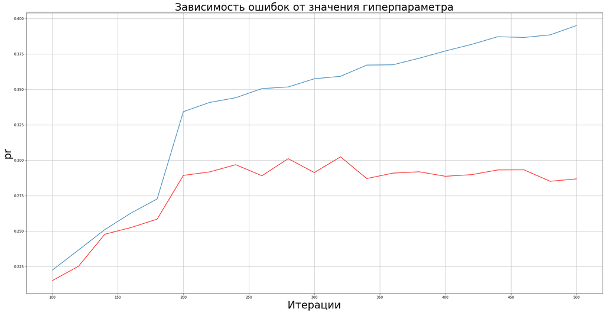

```python
plt.figure(figsize=(30,15))
plt.plot(iterations, all_pr_train)
plt.plot(iterations, all_pr_val, color='red')
plt.ylabel('pr', size = 30)
plt.xlabel('Итерации', size = 30)
plt.title('Зависимость ошибок от значения гиперпараметра', size = 30)
plt.grid()
plt.show()
```

```python
max(all_pr_val)
```

```
0.3023763055730377
```

```python
m = [all_pr_val[i] for i in range(10, 12)]
max(m)
```

```
0.3023763055730377
```

```python
all_pr_val[11]
```

```
0.3023763055730377
```

```python
iterations[11]
```

```
320
```

Видно, что pr на валидация медленно падает, после глобального максимума на 320 итераций. Хотя с кол-ом итераций balance accuracy только улучшается, но в позиции 320 она тоже не плохая.

#### Balanced accuracy train + Balanced accuracy val

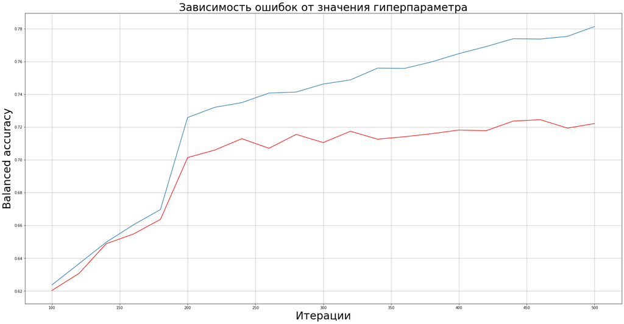

```python
plt.figure(figsize=(30,15))
plt.plot(iterations, all_acc_train)
plt.plot(iterations, all_acc_val, color='red')
plt.ylabel('Balanced accuracy', size = 30)
plt.xlabel('Итерации', size = 30)
plt.title('Зависимость ошибок от значения гиперпараметра', size = 30)
plt.grid()
plt.show()
```

```python
threshold_all[11]
```

```
0.3180143433536258
```

Получается:

- Итераций = 320
- learning_rate = 0.1
- depth = 10
- threshold = 0.32

```python
cat = CatBoostClassifier(verbose=False, iterations=320, learning_rate=0.1, depth=10)
cat.fit(X_train_prepared, y_train)

threshold = 0.32

y_prob_test = cat.predict_proba(X_test_prepared)[:, 1] >= threshold
y_prob_train = cat.predict_proba(X_train_prepared)[:, 1] >= threshold

metrics_table = pd.DataFrame(columns=('train', 'test'))
metrics_table.loc['Average precision score', :] = (average_precision_score(y_train, y_prob_train), \
                                                   average_precision_score(y_test, y_prob_test))
metrics_table.loc['f1-score', :] = (f1_score(y_train, y_prob_train), \
                                    f1_score(y_test, y_prob_test))
metrics_table.loc['Balanced accuracy score', :] = (balanced_accuracy_score(y_train, y_prob_train), \
                                                   balanced_accuracy_score(y_test, y_prob_test))
metrics_table.loc['Accuracy score', :] = (accuracy_score(y_train, y_prob_train), \
                                          accuracy_score(y_test, y_prob_test))
None
```

```python
metrics_table
```

|  | train | test |
| --- | --- | --- |
| Average precision score | 0.667784 | 0.321345 |
| f1-score | 0.792603 | 0.507922 |
| Balanced accuracy score | 0.844036 | 0.696584 |
| Accuracy score | 0.968721 | 0.933893 |

```python
def con_mat(cf_matrix):
    group_names = ['True Neg','False Pos','False Neg','True Pos']
    group_counts = ["{0:0.0f}".format(value) for value in
                    cf_matrix.flatten()]
    group_percentages = ["{0:.2%}".format(value) for value in
                         cf_matrix.flatten()/np.sum(cf_matrix)]
    labels = [f"{v1}\n{v2}\n{v3}" for v1, v2, v3 in
              zip(group_names,group_counts,group_percentages)]
    labels = np.asarray(labels).reshape(2,2)
    sns.heatmap(cf_matrix, annot=labels, fmt='', cmap='Blues')
```

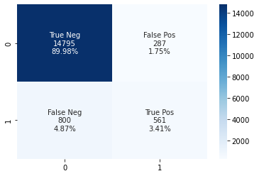

```python
con_mat(confusion_matrix(y_test, y_prob_test))
```

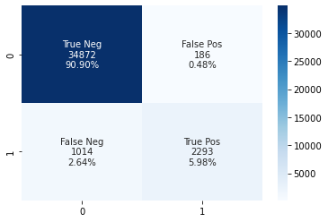

```python
con_mat(confusion_matrix(y_train, y_prob_train))
```

### Сделать общие выводы

Итак, я проанализировала данные и выбросила колонки идентификатора, возраста и пола. Сами выбросы я решила не трогать, потому что не все из них таковыми являются. Заполнили пропуски, кодировали фичи, отмасштабировали, подобрали модель и параметры, получив accuracity **0.93** и balance accuracity **0.697**.

По поводу балансировки - она помогла подобрать параметры получше, однако при реализации финального шага, она сильно переобучалась, поэтому было решено ее убрать.

Результатами я довольна 50/50. Мне кажется их можно сделать лучше. В один момент метрики показывали высокое значение, однако может я напутала что-то или это был баг, но с какого-то запуска модель перестала даже близко показывать такой большой скор.

Рассмотренные модели - **Логистическая регрессия. Решающие деревья, Extra Trees Classifier, Случайный лес, xgboost classifier, CatBoost**.

По поводу результатов, как я и хотела, FP минимизированно. Можно пытаться и FN минимизировать, но это уже другой подход, думаю, основанный на той же идее.